# Lab 2 Clustering

## 0. Setup

Load packages

```r
library(tidyverse)
```

## 1. K-Means Clustering

Create simulated data in which there truly are two clusters. Need to set a seed to ensure reproducible results since the first step of the k_means algorithm is to randomly assign each datapoint to a cluster.

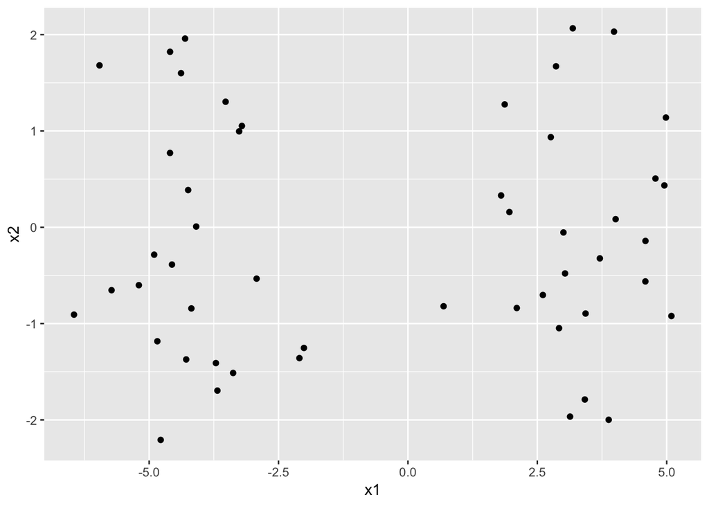

```r
set.seed(2)
sim_data <- tibble("obs" = 1:50, "x1" = rnorm(50), "x2" = rnorm(50)) %>%
  mutate(x1 = if_else(obs <= 25, x1 + 3, x1 - 4))

sim_data %>%
  ggplot(aes(x1, x2)) +
  geom_point()
```

Do K-means clustering with K = 2, ie divide the data into two clusters. Colour each point based on the cluster assigned by k-means, and plot the mean of each cluster.

‘centers’ specifies the number of clusters to divide the data into.

‘nstart’ specifies the number of different initial random assignments to run the k_means algorithm for. If nstart is small (eg 1 or 2), then it is more likely that a local minimum of the within-cluster sum-of-squares will be found. The output from k_means is the run of k_means with the initial random assignment which gives the minimum within-cluster sum-of-squares.

```r
km_out <- sim_data %>%
  select(-obs) %>%
  kmeans(centers = 2, nstart = 20)

km_out
```

```
## K-means clustering with 2 clusters of sizes 25, 25
##
## Cluster means:
##          x1          x2
## 1 -4.195698 -0.18487742
## 2  3.333974 -0.07619104
##
## Clustering vector:
##  [1] 2 2 2 2 2 2 2 2 2 2 2 2 2 2 2 2 2 2 2 2 2 2 2 2 2 1 1 1 1 1 1 1 1 1 1
## [36] 1 1 1 1 1 1 1 1 1 1 1 1 1 1 1
##
## Within cluster sum of squares by cluster:
## [1] 65.40068 63.20595
##  (between_SS / total_SS =  84.6 %)
##
## Available components:
##
## [1] "cluster"      "centers"      "totss"        "withinss"
## [5] "tot.withinss" "betweenss"    "size"         "iter"
## [9] "ifault"
```

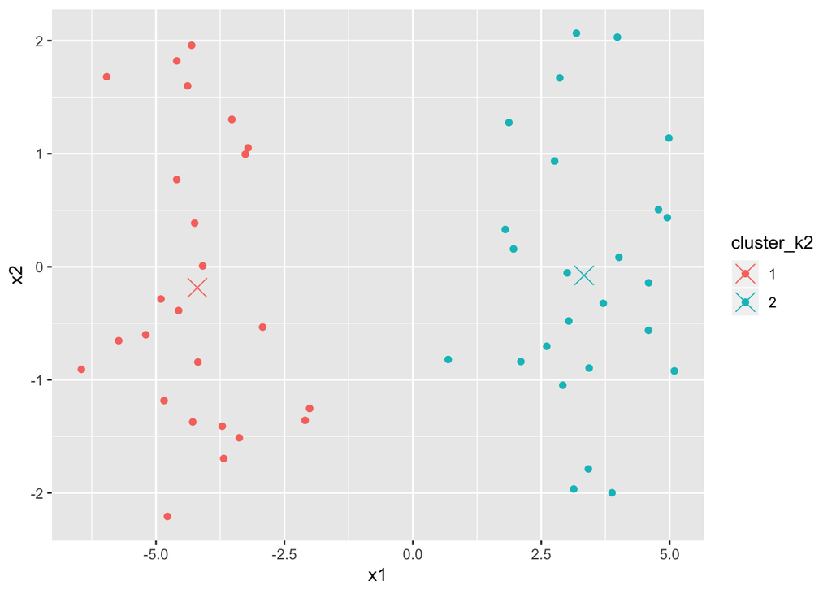

```r
sim_data_out <- sim_data %>%
  mutate(cluster_k2 = as.character(km_out$cluster))

cluster_means <- sim_data_out %>%
  group_by(cluster_k2) %>%
  summarise(x1_mean = mean(x1), x2_mean = mean(x2))

ggplot(sim_data_out, aes(x1, x2, colour = cluster_k2)) +
  geom_point() +
  geom_point(data = cluster_means, aes(x1_mean, x2_mean), size = 5, shape = 4)
```

As above, but with k = 3, ie divide the data into 3 clusters.

```r
km_out <- sim_data %>%
  select(-obs) %>%
  kmeans(centers = 3, nstart = 20)

km_out
```

```
## K-means clustering with 3 clusters of sizes 16, 25, 9
##
## Cluster means:
##          x1          x2
## 1 -4.175870 -1.01221675
## 2  3.333974 -0.07619104
## 3 -4.230947  1.28594806
##
## Clustering vector:
##  [1] 2 2 2 2 2 2 2 2 2 2 2 2 2 2 2 2 2 2 2 2 2 2 2 2 2 1 3 3 3 1 3 1 1 1 1
## [36] 3 1 1 1 3 3 3 1 1 1 1 3 1 1 1
##
## Within cluster sum of squares by cluster:
## [1] 26.982150 63.205951  7.979261
##  (between_SS / total_SS =  88.3 %)
##
## Available components:
##
## [1] "cluster"      "centers"      "totss"        "withinss"
## [5] "tot.withinss" "betweenss"    "size"         "iter"
## [9] "ifault"
```

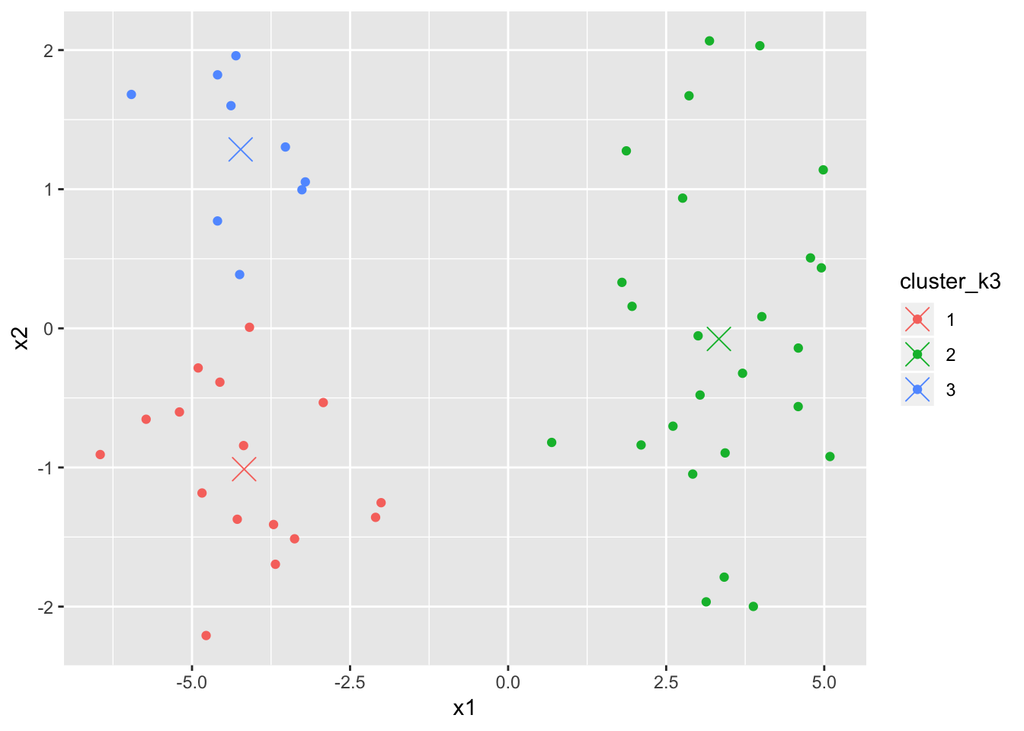

```r
sim_data_out <- sim_data %>%
  mutate(cluster_k3 = as.character(km_out$cluster))

cluster_means <- sim_data_out %>%
  group_by(cluster_k3) %>%
  summarise(x1_mean = mean(x1), x2_mean = mean(x2))

ggplot(sim_data_out, aes(x1, x2, colour = cluster_k3)) +
  geom_point() +
  geom_point(data = cluster_means, aes(x1_mean, x2_mean), size = 5, shape = 4)
```

Investigate effect of varying nstart an centers parameters on the clusters each point is assigned to.

Create a grid of different values for centers (k) and nstart. Apply kmeans to simdata for each pair of values for centers and nstart.

```r
grid <- expand.grid(
  k = seq(from = 2L, to = 3L, by = 1L),
  nstart = seq(from = 1L, by = 10L, length.out = 3L)
  ) %>%
  as_tibble()

grid <- grid %>%
  mutate(data = list(sim_data),
         km_out = purrr::pmap(list("x" = data, "centers" = k, "nstart" = nstart), kmeans)
         )

grid
```

| k | nstart | data | km_out |
| --- | --- | --- | --- |
| 2 | 1 |  |  |
| 3 | 1 |  |  |
| 2 | 11 |  |  |
| 3 | 11 |  |  |
| 2 | 21 |  |  |
| 3 | 21 |  |  |

Add cluster variable to data for each run of kmeans with different values for k and nstart.

```r
# Function to extract vector from kmeans which gives cluster each observation assigned to.
extr_cluster <- function(mod)
  tibble("cluster" = as.character(mod$cluster))

# Function to extract value of total within-cluster sum-of-squares
extr_wcss <- function(mod)
  mod$tot.withinss

grid <- grid %>%
  mutate(cluster = purrr::map(km_out, extr_cluster),
         data = purrr::map2(data, cluster, bind_cols),
         tot.withinss = purrr::map_dbl(km_out, extr_wcss)
        )

grid
```

| k | nstart | data | km_out | cluster | tot.withinss |
| --- | --- | --- | --- | --- | --- |
| 2 | 1 |  |  |  | 2728.607 |
| 3 | 1 |  |  |  | 1516.132 |
| 2 | 11 |  |  |  | 2728.607 |
| 3 | 11 |  |  |  | 1516.132 |
| 2 | 21 |  |  |  | 2728.607 |
| 3 | 21 |  |  |  | 1516.132 |

Plot chart showing clusters observations assigned to for each value of k and nstart. Chart shows that iwith this data the result of kmeans not sensitive to value of nstart, nstart = 1 produces the same results. k = 2 provides better classification than k = 3, as expected given the simulated data.

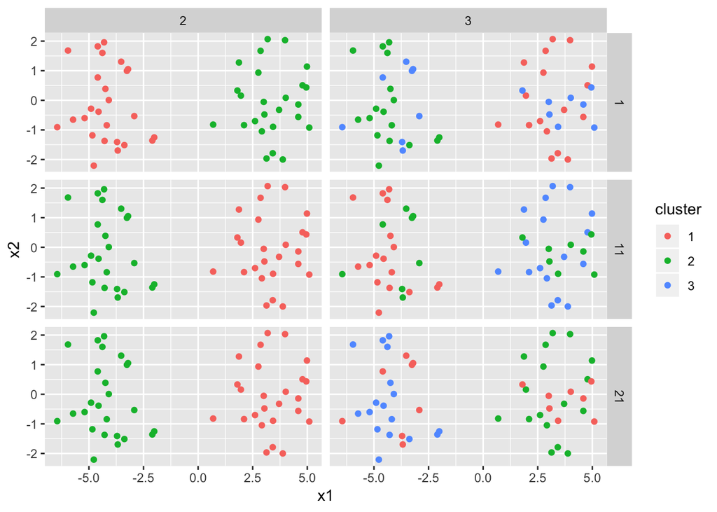

```r
chart_data <- grid %>%
  select(k, nstart, data) %>%
  unnest()

chart_data %>%
  ggplot(aes(x = x1, y = x2, colour = cluster)) +
  geom_point() +
  facet_grid(nstart ~ k)
```

## 2. Hierarchical Clustering

Use hierarchical clustering on the previous dataset to separate data into separate groups. Look at the effect of using different linkage methods. Plot dendogram for each linkage method

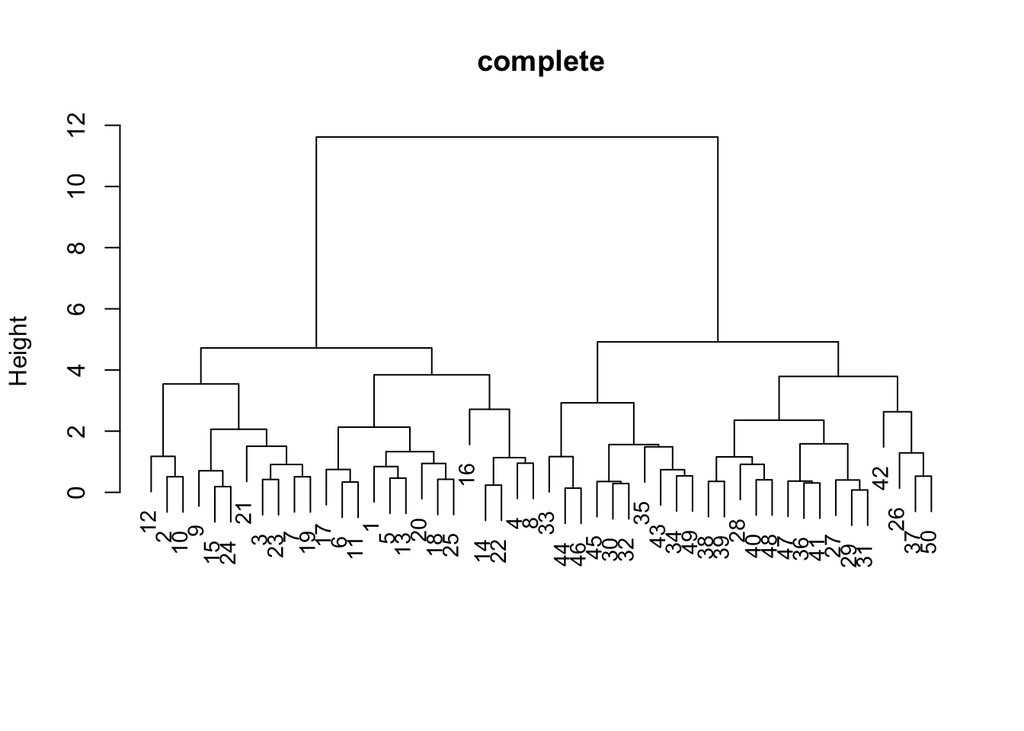

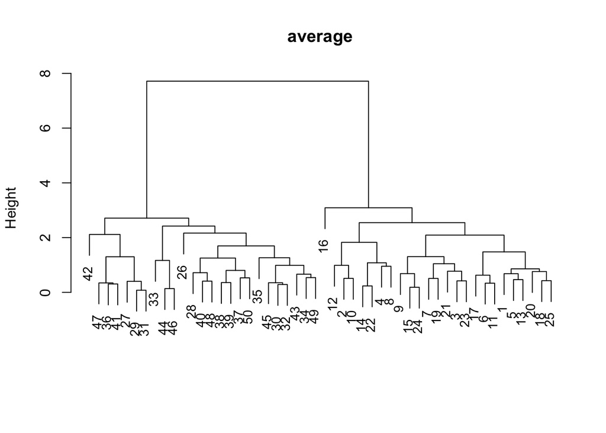

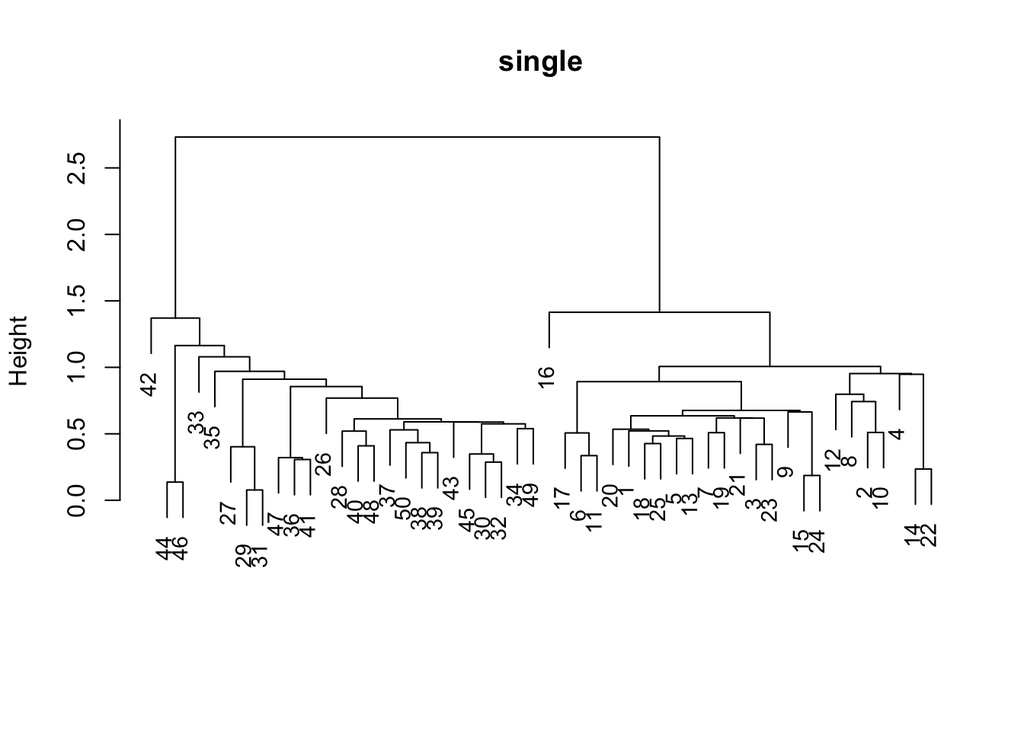

```r
sim_data_no_obs <- select(sim_data, -obs)

hc_df <- tibble("method" = c("complete", "average", "single")) %>%
  mutate(data = list(sim_data_no_obs),
         euc_dist = purrr::map(data, dist),
         hc = purrr::map2(euc_dist, method, hclust))

plot_dgram <- function(hc, method_nm){
  plot(hc, main = method_nm, xlab ="", sub = "", cex = .9)
}

hc_df <- hc_df %>%
  mutate(dgram = purrr::map2(hc, method, plot_dgram)) %>%
  select(-dgram)
```

Return cluster each observation assigned to for the different linkage methods, for k = 2 and k = 3. Show how observations assigned to clusters for different linkage methods and values of k in a chart.

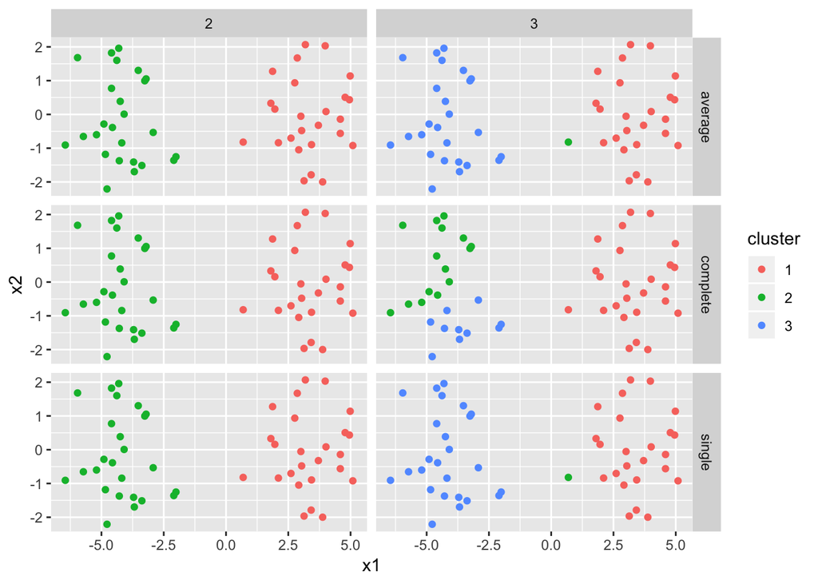

```r
hc_df <- hc_df %>%
  bind_rows(hc_df)

hc_df$k <- rep(2:3, each = 3)

extr_cluster_hc <- function(hc, k){
  tibble("cluster" = as.character(cutree(hc, k)))
}

hc_df <- hc_df %>%
  mutate(cluster = purrr::map2(hc, k, extr_cluster_hc),
         data = purrr::map2(data, cluster, bind_cols))

hc_df %>%
  select(method, k, data) %>%
  unnest() %>%
  ggplot(aes(x = x1, y = x2, colour = cluster)) +
  geom_point() +
  facet_grid(method ~ k)
```